# Austin Traffic Data Analysis

### Prepared by: Alec Neff (UT EID: aen828)

## Part 1: Introduction

The data set chosen for analysis in this project is the “Bluetooth Travel Sensors - Individual Traffic Match Files (IMTF)” data set from the data.austintexas.gov website database. This data was collected by a network of Bluetooth sensors that detected other Bluetooth devices and transmitted the device’s address and time-stamp to a central server. The centralized server that received this data from the network of sensors then generated the data files in this data set.

This data is incredibly important to study for a few main reasons. One reason is that studying ITMF data can provide city planners and engineers with detailed insights into traffic flow patterns, which can help identify where infrastructure improvements are necessary. This problem alone is a huge concern for Austin city officials and the community as a whole, considering the massive tech migration to the Austin-area and sudden population increase. According to Chloe Stavinoha with Aquila Commercial, ([Reference](https://aquilacommercial.com/learning-center/challenges-austin-tx/)), one of Austin’s greatest challenges at this moment is traffic control and city infrastructure. Therefore, this data could unlock some insights that are extremely important for the city to make appropriate changes. Another reason this data is important would be for safety enhancements on the roadways. With a rapidly growing population, more cars generally means more accidents, so identifying unsafe traffic conditions in certain areas can allow for targeted interventions to help improve road safety for the community. I’m particularly interested in this because I plan to live here after school and I drive everywhere. Gaining a stronger understanding of traffic patterns is therefore more interesting to me.

The main variables of interest for this project will be Origin, Final Destination, Speed, Length of Travel, and Day of the Week. These variables will be analyzed to lead to a single outcome variable, Traffic Level, which will represent a congestion score of low, medium, or high congestion. This will also lead to an outcome variable of optimal travel windows, which will be created by analyzing days, times, and traffic levels at specific intersections/routes. A unique row will represent one reading of a Bluetooth device, (vehicle traveling), that has an Origin, Final Destination, Start Time, Speed, Travel Time, Day of the Week, Match Validity, and Congestion Level.

After completing the analysis, I expect to see a strong relationship between travel time and speed traveled, while Austin as a whole having many periods of high or moderate congestion on the roads. My research will attempt to answer the question: How do travel times and speeds vary by day of the week in Austin?

## Part 2: Methods

Read the data into R.

```r
traffic_data <- read_csv("ProjectData.csv")
```

### Description

Description of the data set, reporting the number of rows and columns. In order to wrangle the data, I needed to rename the column names to not include spaces. The original dataset included an end time column along with another identifier column, but I queried the data to exclude these columns to limit the size of the csv file.

```r
#Number of rows
nrow(traffic_data)
```

```
## [1] 43116
```

```r
#Number of cols
ncol(traffic_data)
```

```
## [1] 8
```

```r
#summary stats
summary(traffic_data)
```

```
##  Origin Reader Identifier Destination Reader Identifier Travel Time Seconds
##  Length:43116             Length:43116                  Min.   :  4.00
##  Class :character         Class :character              1st Qu.: 46.00
##  Mode  :character         Mode  :character              Median : 80.00
##                                                         Mean   : 90.22
##                                                         3rd Qu.:120.00
##                                                         Max.   :300.00
##  Speed (Miles Per Hour) Match Validity       Start Time
##  Min.   : 4.00          Length:43116       Min.   :2016-02-01 06:00:09.00
##  1st Qu.:18.00          Class :character   1st Qu.:2016-02-02 13:51:54.75
##  Median :28.00          Mode  :character   Median :2016-02-04 13:44:54.50
##  Mean   :28.59                             Mean   :2016-02-04 11:33:02.71
##  3rd Qu.:38.00                             3rd Qu.:2016-02-05 13:57:24.00
##  Max.   :91.00                             Max.   :2016-02-07 19:12:55.00
##  Day of Week        Device Address
##  Length:43116       Length:43116
##  Class :character   Class :character
##  Mode  :character   Mode  :character
##
##
##
```

```r
#replace spaces with underscores in column names
traffic_data <- traffic_data |>
  rename_with(~ gsub(" ", "_", .x)) |>
  rename(Speed_MPH = `Speed_(Miles_Per_Hour)`)
```

There are 8 columns/variables and 43,116 rows/observations. Summary statistics are also available above. The only cleaning I needed to perform was changing the variable names to be handled in R easily. The resulting data set is tidy because it satisfies all three criteria: each variable has its own column, each observation has it’s own row, and each value has it’s own cell. Every variable had to be re-coded to replace spaces with underscores. “Speed_(Miles_Per_Hour)” also had to be re-coded to exclude the parenthesis at the end of the name so `` wouldn’t be needed.

```r
#display the data set head to show how the data ended up looking
head(traffic_data)
```

```
## # A tibble: 6 × 8
##   Origin_Reader_Identifier Destination_Reader_Id…¹ Travel_Time_Seconds Speed_MPH
##   <chr>                    <chr>                                 <dbl>     <dbl>
## 1 congress_benwhite        congress_stassney                       174        29
## 2 lamar_5th                lamar_6th                                54         6
## 3 congress_6th             congress_5th                             10        25
## 4 rm620_lake_creek         rm620_deerbrook                         172         7
## 5 congress_cesar_chavez    cesar_chavez_red_river                   97        13
## 6 congress_cesar_chavez    cesar_chavez_red_river                   79        16
## # ℹ abbreviated name: ¹Destination_Reader_Identifier
## # ℹ 4 more variables: Match_Validity <chr>, Start_Time <dttm>,
## #   Day_of_Week <chr>, Device_Address <chr>
```

I then wanted to create an outcome variable of the travel congestion level for each observation. To do this, I need to add a new variable of congestion level using mutate. This portion was very challenging, because I needed to find good high & low speed values to separate into different cases. Obviously, speed limits are different along different routes, but given the size of the data set and my beginner level of coding experience, I couldn’t figure out a way to calculate each route’s distance and speed limit. Therefore, I selected the values of 18 mph or less being on the low end, and 38 mph or more to be on the high end. Combining this with travel time could give us a good representation of when traffic is high, moderate or low. For travel time I have selected the high-low values as 46 and 120 seconds, respectively.

```r
#Find the min and max of travel time to know where to set the high and lows
summary(traffic_data$Travel_Time_Seconds)
```

```
##    Min. 1st Qu.  Median    Mean 3rd Qu.    Max.
##    4.00   46.00   80.00   90.22  120.00  300.00
```

```r
#Add a congestion level variable
traffic_data <- traffic_data |>
  mutate(Congestion_Level = case_when(
    #Low traffic case
    Speed_MPH > 38 & Travel_Time_Seconds < 46 ~ "Low",
    #Moderate traffic case
    Speed_MPH <= 38 & Speed_MPH >= 18 & Travel_Time_Seconds >= 46 & Travel_Time_Seconds <= 120 ~ "Moderate",
    #High traffic case
    Speed_MPH < 18 & Travel_Time_Seconds > 120 ~ "High",
    #in case a value doesn't match
    TRUE ~ "Unknown"
  ))

#find new rol col
nrow(traffic_data)
```

```
## [1] 43116
```

```r
ncol(traffic_data)
```

```
## [1] 9
```

After this sorting process, there are now 9 columns, but still 43,116 rows.

## Part 3: Results

Exploring the data with visualizations and summary statistics!

### Numeric Variable: Uni-variate Distribution

Below is a uni-variate distribution of the speeds that were observed across the entire data set.

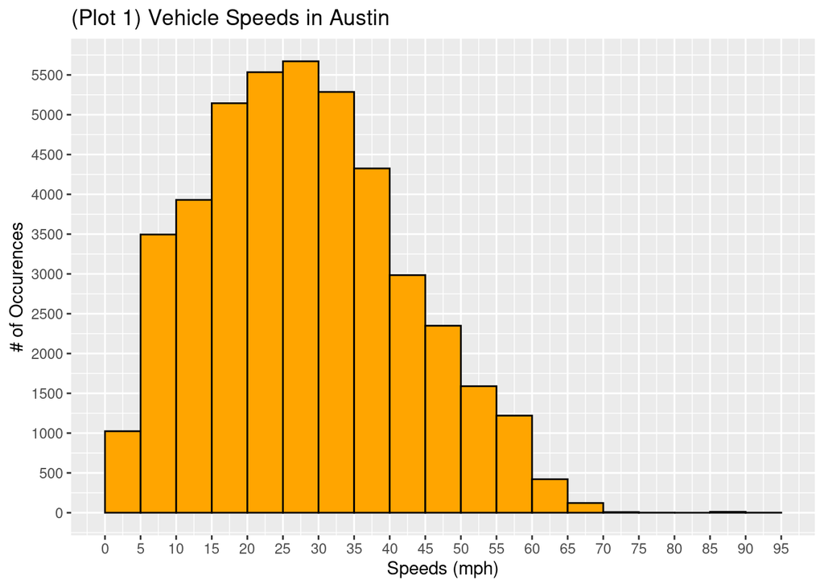

```r
#Plot the traffic data
ggplot(data = traffic_data) +
  #Create a histogram for the speeds traveled with appropriate binwidths
  geom_histogram(aes(x = Speed_MPH), binwidth = 5, center = 2.5, color = "black", fill = "orange") +
  #label the plot
  labs(x = "Speeds (mph)", y = "# of Occurences", title = "(Plot 1) Vehicle Speeds in Austin") +
  #scale the axes
  scale_x_continuous(breaks = seq(0, 100, 5)) +
  scale_y_continuous(breaks = seq(0, 6000, 500))
```

```r
#give some summary statistics about the plot
summary(traffic_data$Speed_MPH)
```

```
##    Min. 1st Qu.  Median    Mean 3rd Qu.    Max.
##    4.00   18.00   28.00   28.59   38.00   91.00
```

```r
#find the mean
mean_speed <- mean(traffic_data$Speed_MPH)
#find the standard deviation
sd_speed <- sd(traffic_data$Speed_MPH)
#print the mean and standard deviation
mean_speed
```

```
## [1] 28.59064
```

```r
sd_speed
```

```
## [1] 14.03828
```

```r
#represent both ends of the standard deviation on the data
mean_speed - sd_speed
```

```
## [1] 14.55235
```

```r
mean_speed + sd_speed
```

```
## [1] 42.62892
```

**Note. We can see that the majority of driving is done between 15-40mpg in Austin, with the mean being 28.59 mph and a standard deviation of 14.03828 mph. The median being close to the mean at 28.00 mph. By applying the standard deviation to the mean, we can assume that 68% of the data lies between 14.55235 and 42.62892 mph.**

### Categorical Variable: Uni-variate Distribution

Below is a uni-variate distribution of the days of the week that were observed across the entire data set.

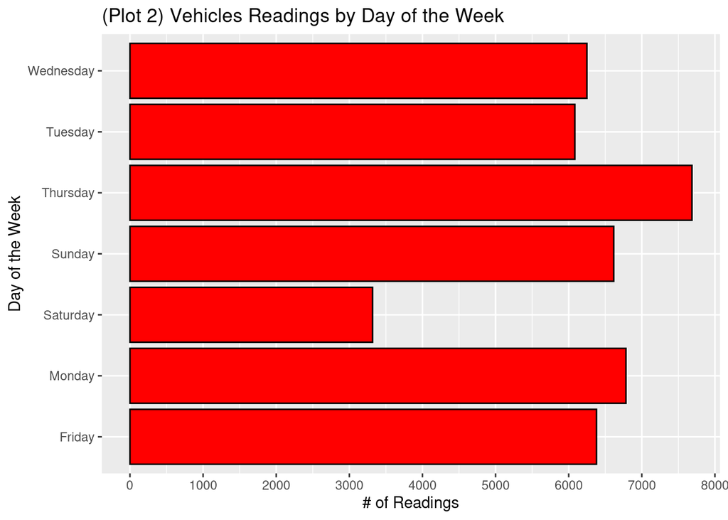

```r
#Plot the categorical variable by each day of the week
ggplot(data = traffic_data) +
  # Use geom_histogram and define mapping aesthetics
  geom_bar(aes(x = Day_of_Week), fill = "red", color = "black") +
  #label the plot
  labs(title = '(Plot 2) Vehicles Readings by Day of the Week', x = 'Day of the Week', y = '# of Readings') +
  #scale the readings axis
  scale_y_continuous(breaks = seq(0, 8000, 1000)) +
  #flip for readability
  coord_flip()
```

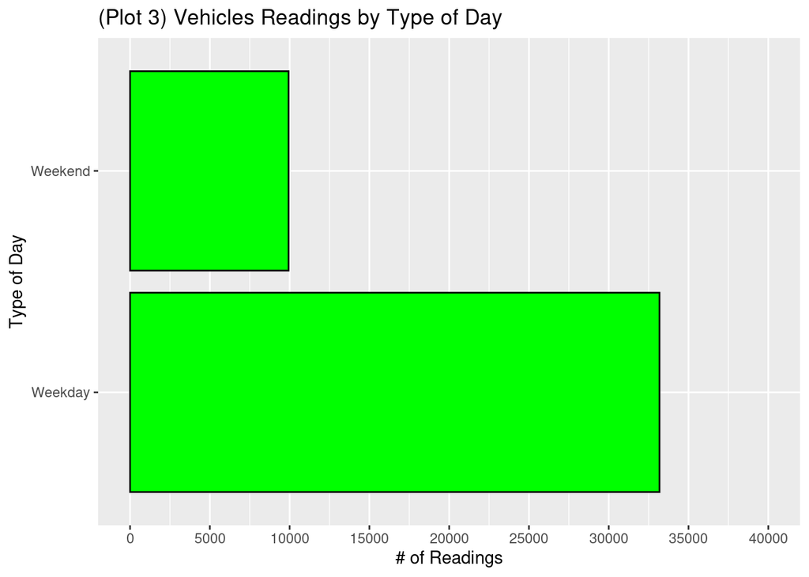

```r
#Group by weekday or weekend to plot
new_data <- mutate(traffic_data, days_2cat = ifelse(Day_of_Week == "Sunday" |   Day_of_Week == "Saturday", "Weekend", "Weekday"))
#Plot weekday vs weekend
ggplot(data = new_data) +
   # Use geom_histogram and define mapping aesthetics
  geom_bar(aes(x = days_2cat), fill = "green", color = "black") +
  #label the plot
  labs(title = '(Plot 3) Vehicles Readings by Type of Day', x = 'Type of Day', y = '# of Readings') +
  #scale the readings axis
  scale_y_continuous(limits = c(0, 40000), breaks = seq(0, 40000, 5000)) +
  #flip for readability
  coord_flip()
```

```r
#Find the summary statistics for each
summary_table <- table(traffic_data$Day_of_Week)
summary_table
```

```
##
##    Friday    Monday  Saturday    Sunday  Thursday   Tuesday Wednesday
##      6380      6783      3318      6616      7686      6084      6249
```

```r
table_2cat <- table(new_data$days_2cat)
table_2cat
```

```
##
## Weekday Weekend
##   33182    9934
```

### Numeric Variable: Bi-variate Distribution

Below is a bi-variate distribution of the speeds that were observed and their relationship to travel time. This relationship is fundamental in traffic analysis because a model can be made for the general amount of time it should take to travel while moving at a given speed.

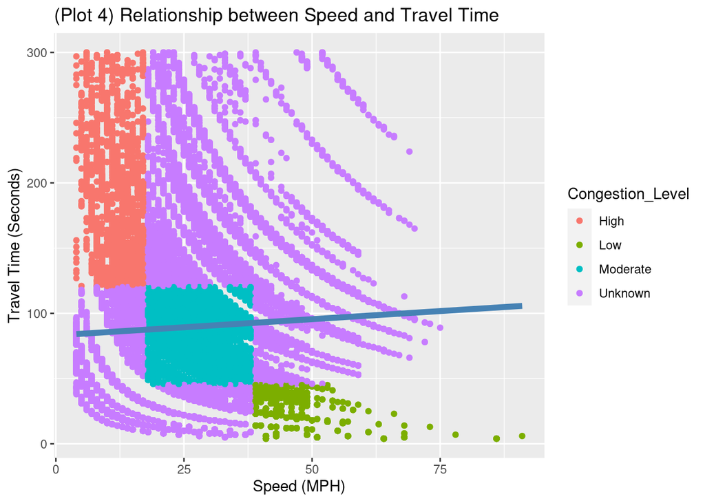

```r
#Plot the relationship
ggplot(data = traffic_data, aes(x = Speed_MPH, y = Travel_Time_Seconds)) +
  #use a scatter plot
  geom_point(aes(color = Congestion_Level)) +
  #put a regression line on the plot
  geom_smooth(method = "lm", se = FALSE, color = "steelblue", linewidth = 2) +
  #label the plot appropriately
  labs(x = "Speed (MPH)", y = "Travel Time (Seconds)", title = "(Plot 4) Relationship between Speed and Travel Time") #+
```

```r
#find summary statistics using R^2 and RMSE
#find lin regresion model
fit_lin <- lm(Travel_Time_Seconds ~ Speed_MPH, data = traffic_data)
#summary expression
summary(fit_lin)
```

```
##
## Call:
## lm(formula = Travel_Time_Seconds ~ Speed_MPH, data = traffic_data)
##
## Residuals:
##     Min      1Q  Median      3Q     Max
## -100.46  -43.08  -10.56   28.47  215.38
##
## Coefficients:
##             Estimate Std. Error t value Pr(>|t|)
## (Intercept)  83.1292     0.6404  129.82   <2e-16 ***
## Speed_MPH     0.2481     0.0201   12.34   <2e-16 ***
## ---
## Signif. codes:  0 '***' 0.001 '**' 0.01 '*' 0.05 '.' 0.1 ' ' 1
##
## Residual standard error: 58.6 on 43114 degrees of freedom
## Multiple R-squared:  0.003519,   Adjusted R-squared:  0.003496
## F-statistic: 152.3 on 1 and 43114 DF,  p-value: < 2.2e-16
```

```r
#evaluate first RMSE of model
sqrt(mean(resid(fit_lin)^2))
```

```
## [1] 58.60258
```

```r
#evaluate the r adjusted
summary(fit_lin)$adj.r.squared
```

```
## [1] 0.003496055
```

**Note. This plot shows that there is likely a hyperbolic relationship between speed and travel time. More will be discussed in the discussion section. But the summary statistics of RMSE and R^2, 58.6 and 0.00349 respectively, show that there is a weak linear relationship between the variables.**

### Categorical vs. Numerical : Bi-variate Distribution

Below is a bi-variate distribution of the travel times in relationship to day of the week.

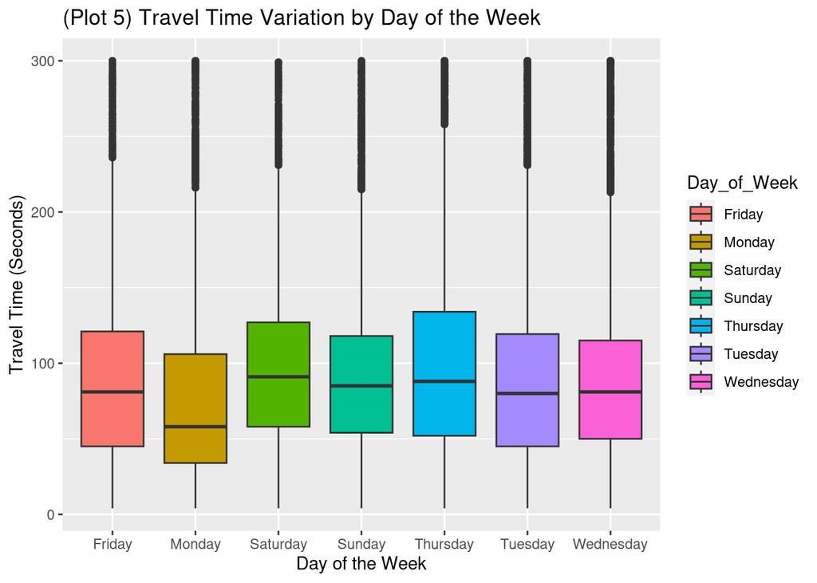

```r
#Plot the relationship
ggplot(data = traffic_data, aes(x = Day_of_Week, y = Travel_Time_Seconds, fill = Day_of_Week)) +
  #use a boxplot to represent the data
  geom_boxplot() +
  #label the plot appropriately
  labs(x = "Day of the Week", y = "Travel Time (Seconds)", title = "(Plot 5) Travel Time Variation by Day of the Week")
```

```r
#For summary statistics
summary_stats <- traffic_data |>
  group_by(Day_of_Week) |>
  #Find each summary stat below (mean, median, standard devication, min and max)
  summarize(
    Mean_Travel_Time = mean(Travel_Time_Seconds, na.rm = T),
    Median_Travel_Time = median(Travel_Time_Seconds, na.rm = T),
    SD_Travel_Time = sd(Travel_Time_Seconds, na.rm = T),
    Min_Travel_Time = min(Travel_Time_Seconds, na.rm = T),
    Max_Travel_Time = max(Travel_Time_Seconds, na.rm = T),
    Count = n())
#display the summary stats
summary_stats
```

```
## # A tibble: 7 × 7
##   Day_of_Week Mean_Travel_Time Median_Travel_Time SD_Travel_Time Min_Travel_Time
##   <chr>                  <dbl>              <dbl>          <dbl>           <dbl>
## 1 Friday                  89.4                 81           57.4               4
## 2 Monday                  76.3                 58           57.7               4
## 3 Saturday                98.0                 91           56.8               4
## 4 Sunday                  91.4                 85           53.6               4
## 5 Thursday                99.5                 88           63.1               4
## 6 Tuesday                 91.2                 80           61.9               4
## 7 Wednesday               88.4                 81           55.3               4
## # ℹ 2 more variables: Max_Travel_Time <dbl>, Count <int>
```

### Categorical vs. Categorical: Bi-variate Distribution

Below is a bi-variate distribution congestion levels in relationship to day of the week.

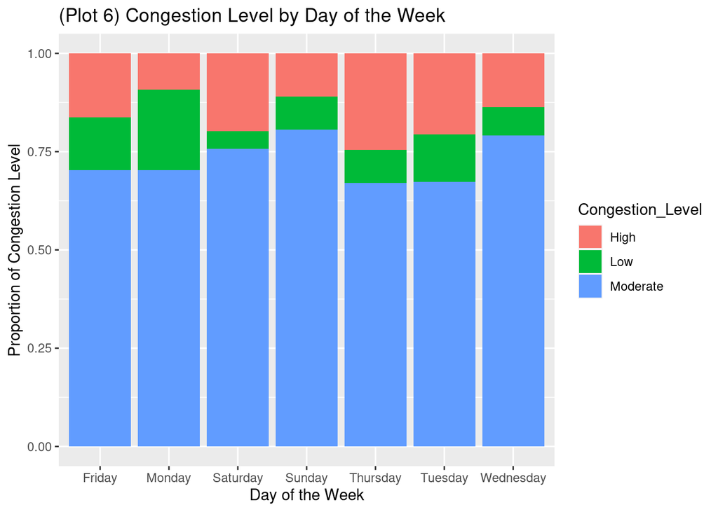

```r
# Plot the relationship
traffic_data |>
  #filter to only classified congsetion data
  filter(Congestion_Level != "Unknown") |>
#plot the findings
ggplot(aes(x = Day_of_Week, fill = Congestion_Level)) +
  #use a fill bar
  geom_bar(position = "fill") +
  #label the graph
  labs(x = "Day of the Week", y = "Proportion of Congestion Level", title = "(Plot 6) Congestion Level by Day of the Week")
```

```r
  #use general color values
#find the frequencies of each value as summary stats
table(traffic_data$Congestion_Level, traffic_data$Day_of_Week)
```

```
##
##            Friday Monday Saturday Sunday Thursday Tuesday Wednesday
##   High        345    173      287    302      783     467       347
##   Low         285    387       65    230      267     275       182
##   Moderate   1493   1328     1097   2203     2131    1529      2008
##   Unknown    4257   4895     1869   3881     4505    3813      3712
```

**Note. We can see from the plot that the majority of classified traffic congestion level values are moderate traffic, which makes sense. Monday has the largest proportion of low congestion levels, while Saturday and Thursday appear to have a largest proportion of high congestion traffic levels. That being said, from the table above, we can also see that a large proportion of values were excluded from the analysis due to the classification constraints. For that reason, a more detailed model would likely be needed and will be discussed in the discussion section.**

## Part 3b: Predict an Outcome

I already created an outcome variable using linear regression, but it performed poorly. So let’s try again using our calculated congestion levels and Speed.

### Numeric Variable Prediction

Below is a model to predict the travel time of a traveler given their driving speed and the Predicted Congestion Level using a linear model to predict a continuous variable.

```r
#fit the model using a linear regression
traffic_reg <- lm(Travel_Time_Seconds ~ Speed_MPH + Congestion_Level, data = traffic_data)
#summary of model
summary(traffic_reg)
```

```
##
## Call:
## lm(formula = Travel_Time_Seconds ~ Speed_MPH + Congestion_Level,
##     data = traffic_data)
##
## Residuals:
##     Min      1Q  Median      3Q     Max
## -91.758 -34.729  -7.398  25.356 220.651
##
## Coefficients:
##                           Estimate Std. Error t value Pr(>|t|)
## (Intercept)               165.7088     0.9984  165.97   <2e-16 ***
## Speed_MPH                   1.0783     0.0188   57.35   <2e-16 ***
## Congestion_LevelLow      -188.3519     1.6898 -111.47   <2e-16 ***
## Congestion_LevelModerate -117.7199     1.1213 -104.98   <2e-16 ***
## Congestion_LevelUnknown  -106.8478     1.0737  -99.52   <2e-16 ***
## ---
## Signif. codes:  0 '***' 0.001 '**' 0.01 '*' 0.05 '.' 0.1 ' ' 1
##
## Residual standard error: 50.61 on 43111 degrees of freedom
## Multiple R-squared:  0.2567, Adjusted R-squared:  0.2567
## F-statistic:  3723 on 4 and 43111 DF,  p-value: < 2.2e-16
```

```r
#predict the values using our model
traffic_data |>
  #add the predicted variable
  mutate(predicted = predict(traffic_reg)) |>
  #look at necessary variables
  select(Travel_Time_Seconds, Speed_MPH, Congestion_Level, predicted)
```

```
## # A tibble: 43,116 × 4
##    Travel_Time_Seconds Speed_MPH Congestion_Level predicted
##                  <dbl>     <dbl> <chr>                <dbl>
##  1                 174        29 Unknown               90.1
##  2                  54         6 Unknown               65.3
##  3                  10        25 Unknown               85.8
##  4                 172         7 High                 173.
##  5                  97        13 Unknown               72.9
##  6                  79        16 Unknown               76.1
##  7                  13        42 Low                   22.6
##  8                  23        15 Unknown               75.0
##  9                  58        35 Moderate              85.7
## 10                  51        11 Unknown               70.7
## # ℹ 43,106 more rows
```

```r
#evaluate first RMSE of model
sqrt(mean(resid(traffic_reg)^2))
```

```
## [1] 50.61173
```

```r
#evaluate the r adjusted
summary(traffic_reg)$adj.r.squared
```

```
## [1] 0.2566761
```

```r
#Cross validation
# Make this example reproducible by setting a seed
set.seed(322)

#perform 5-fold cross-validation with 5 folds
k = 5

#randomly order rows
data <- traffic_data[sample(nrow(traffic_data)), ]

#create k folds from the dataset (5)
folds <- cut(seq(1:nrow(data)), breaks = k, labels = FALSE)

#initialize the vector to check performance
perf_k <- NULL

# Use a for-loop to get performance for each k-fold
for(i in 1:k){
  # Split data into train and test data
  train_not_i <- data[folds != i, ] # train data = all observations except in fold i
  test_i <- data[folds == i, ]  # test data = observations in fold i

  # Train model on train data (all but fold i)
  train_model <- lm(Travel_Time_Seconds ~ Speed_MPH + Congestion_Level, data = train_not_i)

  # Performance listed for each test data = fold i
  perf_k[i] <- sqrt(mean((
    test_i$Travel_Time_Seconds - predict(train_model, newdata = test_i))^2,
    na.rm = TRUE))
}

# Performance for each fold
perf_k
```

```
## [1] 50.43146 50.40450 50.09135 51.07173 51.06805
```

```r
#average performance over all folds
mean(perf_k)
```

```
## [1] 50.61342
```

```r
#Standard deviation (sd)
sd(perf_k)
```

```
## [1] 0.4376218
```

**Note. As we can see from the model, the RMSE of this model is still high, but is lower than the previous one only using Speed_MPH as a predictor by about 8. This likely means our congestion level outcome variable does have a predictive affect on the model. The RMSE is approximately 50.61 and the std is ~ 0.44, which so the mean is still high. Our cross validation shows the performance for each fold, which indicates the model is still underfitting. The R^2 adjusted value is also significantly higher than our previous model, but still not great, at a value of ~0.26. Overall, the model would not take accurately to new data, but it does better than the previous model.**

## Part 4: Discussion

After working through the data with several visualizations and summary statistics, the main takeaways and answers to my research question are pretty apparent. In the beginning, I proposed the research question of: How do travel times and speeds vary by day of the week in Austin? In order to begin the analysis, I visualized the distributions of travel speeds, and days of the week that were contained in the data set (Plots 1-3). From there, I wanted to visualize my outcome variable, Congestion Level, which was strategically created to represent high, moderate, and low congestion levels for each value in the data set.

The first main takeaway from my analysis is that a complicated machine learning model might be needed to accurately represent the relationship between speed and travel times around every location in Austin. I quickly figured out that I wouldn’t be able to compare every route to other observations on that route, and rather than select a few target routes to analyze, I believed that representing the overall trends would be more beneficial for this purpose by constructing a classification variable. In doing so, it raised one of the biggest flaws of my work, which is that some important data might be excluded based on the cutoff criteria no matter how hard I try to create accurate cutoffs for my classification. While balancing your results is an important aspect of data science, the data set didn’t have a variable representing traffic levels so there was no way to compare true/false positive/negative values within my analysis. That being said, I believe that my cutoff criteria was the best representation of the data.

The other main takeaway from my research is that a moderate traffic level is very common in Austin, Texas. However, after applying my case criteria for high, moderate and low congestion levels, the table attached to Plot 6 showed than many of the data points were classified as unknown because they didn’t identify with any of the three levels. This was not what I expected, and actually directly contradicts it. I predicted that Austin would almost exclusively experience high or moderate traffic levels, and that they would be easily classifiable because travel time and speed would be tightly correlated. Both of those assumptions wound up being false, shown in Plots 4 and 6. The the summary statistics of RMSE and R^2 for my linear model in plot 4 were 58.6 and 0.00349, respectively. This correlation is horrible, enough to be tossed out entirely as being related. This could likely be due to traffic patterns being so different across different times, days, holidays, construction zones, and accidents. If I had a partner, I could have potentially joined a data set representing accidents in the Austin area and merged into a new data set to investigate further. I’m curious if I had analyzed traffic congestion level and compared it to the time of day being between a certain period, if a lot of the high congestion zones would have been during rush hour times.

As far as possible impacts or implications of my results, there are definitely some concerns related to privacy of Bluetooth device owners. By prioritizing data privacy and ensuring the anonymization technique of Bluetooth device addressed, we can mitigate privacy concerns to protect individuals data while still gaining valuable insights into traffic patterns. Additionally, addressing bias and fairness in the analysis ensures that traffic management solutions benefit all areas of a city, not just the most congested, promoting equitable improvements across the constituents.

There is nothing at this time about the data set itself that I would like to report. I did not encounter any typos, missing values, or inconsistent categories.

## Part 5: Reflection

This project was incredibly insightful in how a real data scientist might try and tackle a real world problem. The most challenging aspect of the project for me was getting the data to answer the question that I wanted answered. Originally when thinking about using this data set, I wanted to analyze traffic patterns to identify times of high traffic congestion, and maybe determine routes around the city to avoid at certain times. I quickly realized that doing so would require me to analyze each route specifically or map out each route to analyze. Considering there are 83 unique sensors that can travel to any of the other 82 potential sensors, that means there are 6,806 potentially routes to analyze. Obviously, that is too many, so I choose my classification method instead which I think worked out well to count totals, but not perform linear regression.

```r
#find the distinct number of identifiers
n_distinct(traffic_data$Origin_Reader_Identifier)
```

```
## [1] 83
```

```r
n_distinct(traffic_data$Destination_Reader_Identifier)
```

```
## [1] 83
```

```r
#how many possible routes are there?
83*82
```

```
## [1] 6806
```

After completing the project, I have learned a lot about what it means to analyze data within the scope of your own research question. Everything that I have done up until this point has been laid out for me, and I can make small decisions here and there. This time around, I had to make every decision when it came down to how I wanted to analyze the speeds, travel times, and traffic levels. Not only did I have to make those decisions, but I had to come up with ways to work around the challenges and find a way to analyze the data appropriately to get results.

I would like to thank Dr. Layla Guyot, Graduate TA Ciara Nugent, Undergraduate TA’s Dustyn and Vaishnavi, and the City of Austin for helping me along the journey of completing this project.

## References:

Data set: https://data.austintexas.gov/Transportation-and-Mobility/Bluetooth-Travel-Sensors-Individual-Traffic-Match-/x44q-icha/about_data

Article: https://aquilacommercial.com/learning-center/challenges-austin-tx/